# Edinburgh Footfall Analysis

Here's a short notebook that serves as a small guide on how to do some basic data analysis with Python (using `pandas`, `matplotlib`, `scikit-learn` and a bit of `numpy`) on a real dataset I came across online.

## Part 1 - Fetching Data

First thing we want to do is get the data.

We can either manually download it from: http://www.edinburghopendata.info/dataset/monthly-footfall-data, or (once we know the direct links to the data) we can have Python automatically download it so when someone goes to recreate this analysis they don't have to go searching.

```python
#direct links to data

urls = ['http://www.edinburghopendata.info/dataset/41586704-092d-4afe-b634-4fb7ea20fedd/resource/9762f4b7-ba25-40f2-a707-94d45956d916/download/footfall2012.zip',
        'http://www.edinburghopendata.info/dataset/41586704-092d-4afe-b634-4fb7ea20fedd/resource/993bb312-3bb3-4c41-b1ba-8239adeb16ac/download/footfall2013.zip',
        'http://www.edinburghopendata.info/dataset/41586704-092d-4afe-b634-4fb7ea20fedd/resource/ba2e9ae6-0c84-457d-8d6c-6ff303ed244f/download/footfall2014.zip']

#urllib.requests for handing URLs, urlretrieve to download from a URL

from urllib.request import urlretrieve

#i'm using a list comprehension to make it look nice, basically just downloading each of the years worth of footfalls
#by calling 'urlretrieve' on the url, saving it into the 'data' folder with the filename being the .zip name
#get the .zip name by splitting the url into "chunks" separated by '/' and getting the final chunk

[urlretrieve(url, 'data/%s' % url.split('/')[-1]) for url in urls];
```

Now we have the zip files downloaded, we want to extract each one to get the .csv files containing the actual data.

```python
import os, zipfile

#get a list with each element being the name of the file

files = os.listdir('data/')

#for each file, convert into ZipFile object and then perform extractall on it

[zipfile.ZipFile('data/%s' % file).extractall('data/') for file in files if file.endswith('.zip')];
```

## Part 2 - Refactoring Data

Let's view the contents of one of these .csv files

```python
import pandas as pd

data = pd.read_csv('data/footfall-201203.csv')
data.head()
```

|  | Day | Date | Leith Walk: Vittoria (Springboard) | Princes St: Marks & Spencer | George Street: NatWest | George Street: French Connection, FCUK | Rose Street: Tiso | Rose St: Jenners | South St Andrew Street: McDonalds | Shandwick Pl: Lothian Buses | Grassmarket: Grassmarket Hotel | High Street: Bella Italia |
| --- | --- | --- | --- | --- | --- | --- | --- | --- | --- | --- | --- | --- |
| 0 | Thursday | 01/03/2012 | 6,165 | 34,818 | 23,458 | 15,417 | 10,655 | 10,582 | 9,512 | NaN | NaN | NaN |
| 1 | Friday | 02/03/2012 | 6,906 | 28,547 | 15,760 | 12,428 | 9,040 | 8,066 | 8,877 | NaN | NaN | NaN |
| 2 | Saturday | 03/03/2012 | 7,435 | 37,333 | 18,762 | 19,259 | 11,980 | 6,781 | 12,328 | NaN | NaN | NaN |
| 3 | Sunday | 04/03/2012 | 5,628 | 21,536 | 9,809 | 9,931 | 5,460 | 3,751 | 7,169 | NaN | NaN | NaN |
| 4 | Monday | 05/03/2012 | 5,887 | 22,763 | 14,525 | 11,956 | 5,989 | 7,556 | 6,109 | NaN | NaN | NaN |

All .csv files have the same headers. A few issues though:

- the data from 2012 is only from March onwards
- the data for "Shandwick Pl: Lothian Buses" doesn't appear until May 2012
- the data for "Grassmarket: Grassmarket Hotel" and "High Street: Bella Italia" don't appear until May 2013
- the data for "High Street: Bella Italia" stops appearing after May 2014 (potentially was only collected for that one year)

To make things a bit easier to analyse, we'll ignore data for the last three locations.

```python
#get all the csv files, ignoring the zip files

all_csv_files = [file for file in os.listdir('data/') if file.endswith('.csv')]

#concatenate them together into one big dataframe
#we use the thousands=',' to tell pandas this data is an integer using a comma to separate the thousands from the hundreds

data = pd.concat((pd.read_csv('data/%s' % file, thousands=',') for file in all_csv_files))

print(data.shape)

data.head()
```

```
(1036, 12)
```

|  | Day | Date | Leith Walk: Vittoria (Springboard) | Princes St: Marks & Spencer | George Street: NatWest | George Street: French Connection, FCUK | Rose Street: Tiso | Rose St: Jenners | South St Andrew Street: McDonalds | Shandwick Pl: Lothian Buses | Grassmarket: Grassmarket Hotel | High Street: Bella Italia |
| --- | --- | --- | --- | --- | --- | --- | --- | --- | --- | --- | --- | --- |
| 0 | Thursday | 01/03/2012 | 6165 | 34818 | 23458 | 15417 | 10655 | 10582 | 9512 | NaN | NaN | NaN |
| 1 | Friday | 02/03/2012 | 6906 | 28547 | 15760 | 12428 | 9040 | 8066 | 8877 | NaN | NaN | NaN |
| 2 | Saturday | 03/03/2012 | 7435 | 37333 | 18762 | 19259 | 11980 | 6781 | 12328 | NaN | NaN | NaN |
| 3 | Sunday | 04/03/2012 | 5628 | 21536 | 9809 | 9931 | 5460 | 3751 | 7169 | NaN | NaN | NaN |
| 4 | Monday | 05/03/2012 | 5887 | 22763 | 14525 | 11956 | 5989 | 7556 | 6109 | NaN | NaN | NaN |

Now to drop those last three columns. We'll also remove the 'Day' column as we won't be using it.

```python
#.drop method to remove data from a dataframe
#first argument is what to drop, here the last 3 columns
#use axis = 1 to drop columns (default is axis = 0, which is rows)
#inplace=True means it automatically applies it to the dataframe, saves us doing data = data.drop(...)

data.drop(data.columns[-3:], axis=1, inplace=True)

data.head()
```

|  | Day | Date | Leith Walk: Vittoria (Springboard) | Princes St: Marks & Spencer | George Street: NatWest | George Street: French Connection, FCUK | Rose Street: Tiso | Rose St: Jenners | South St Andrew Street: McDonalds |
| --- | --- | --- | --- | --- | --- | --- | --- | --- | --- |
| 0 | Thursday | 01/03/2012 | 6165 | 34818 | 23458 | 15417 | 10655 | 10582 | 9512 |
| 1 | Friday | 02/03/2012 | 6906 | 28547 | 15760 | 12428 | 9040 | 8066 | 8877 |
| 2 | Saturday | 03/03/2012 | 7435 | 37333 | 18762 | 19259 | 11980 | 6781 | 12328 |
| 3 | Sunday | 04/03/2012 | 5628 | 21536 | 9809 | 9931 | 5460 | 3751 | 7169 |
| 4 | Monday | 05/03/2012 | 5887 | 22763 | 14525 | 11956 | 5989 | 7556 | 6109 |

And now to drop the 'Day' column.

```python
data.drop('Day', axis=1, inplace=True)

data.head()
```

|  | Date | Leith Walk: Vittoria (Springboard) | Princes St: Marks & Spencer | George Street: NatWest | George Street: French Connection, FCUK | Rose Street: Tiso | Rose St: Jenners | South St Andrew Street: McDonalds |
| --- | --- | --- | --- | --- | --- | --- | --- | --- |
| 0 | 01/03/2012 | 6165 | 34818 | 23458 | 15417 | 10655 | 10582 | 9512 |
| 1 | 02/03/2012 | 6906 | 28547 | 15760 | 12428 | 9040 | 8066 | 8877 |
| 2 | 03/03/2012 | 7435 | 37333 | 18762 | 19259 | 11980 | 6781 | 12328 |
| 3 | 04/03/2012 | 5628 | 21536 | 9809 | 9931 | 5460 | 3751 | 7169 |
| 4 | 05/03/2012 | 5887 | 22763 | 14525 | 11956 | 5989 | 7556 | 6109 |

The last thing we have to do before plotting the data is make sure the data types are correct.

```python
data.dtypes
```

```
Date                                      object
Leith Walk:  Vittoria (Springboard)        int64
Princes St:  Marks & Spencer               int64
George Street: NatWest                     int64
George Street: French Connection, FCUK     int64
Rose Street: Tiso                          int64
Rose St: Jenners                           int64
South St Andrew Street: McDonalds          int64
dtype: object
```

When we used `thousands=','` when reading the .csv files `pandas` automatically infered the types for most of the columns, however it left 'Date' as an 'object' & we want it to be a 'datetime'. To sort this out, we'll just convert it using `to_datetime`.

```python
data['Date'] = pd.to_datetime(data['Date'], format='%d/%m/%Y') #need to state how the dates are formatted

data.head()
```

|  | Date | Leith Walk: Vittoria (Springboard) | Princes St: Marks & Spencer | George Street: NatWest | George Street: French Connection, FCUK | Rose Street: Tiso | Rose St: Jenners | South St Andrew Street: McDonalds |
| --- | --- | --- | --- | --- | --- | --- | --- | --- |
| 0 | 2012-03-01 | 6165 | 34818 | 23458 | 15417 | 10655 | 10582 | 9512 |
| 1 | 2012-03-02 | 6906 | 28547 | 15760 | 12428 | 9040 | 8066 | 8877 |
| 2 | 2012-03-03 | 7435 | 37333 | 18762 | 19259 | 11980 | 6781 | 12328 |
| 3 | 2012-03-04 | 5628 | 21536 | 9809 | 9931 | 5460 | 3751 | 7169 |
| 4 | 2012-03-05 | 5887 | 22763 | 14525 | 11956 | 5989 | 7556 | 6109 |

```python
data.dtypes
```

```
Date                                      datetime64[ns]
Leith Walk:  Vittoria (Springboard)                int64
Princes St:  Marks & Spencer                       int64
George Street: NatWest                             int64
George Street: French Connection, FCUK             int64
Rose Street: Tiso                                  int64
Rose St: Jenners                                   int64
South St Andrew Street: McDonalds                  int64
dtype: object
```

## Part 3 - Visualizing Data

Now we can finally plot the data using `matplotlib`. We'll plot it as a line and as a scatterplot.

`%matplotlin inline` allows for plotting matplotlib graphs without the `.show()` method.

Note: by default `pandas` doesn't let you scatterplot using `datetime` axis, but if you change the `style` of a line plot you basically get a scatterplot.

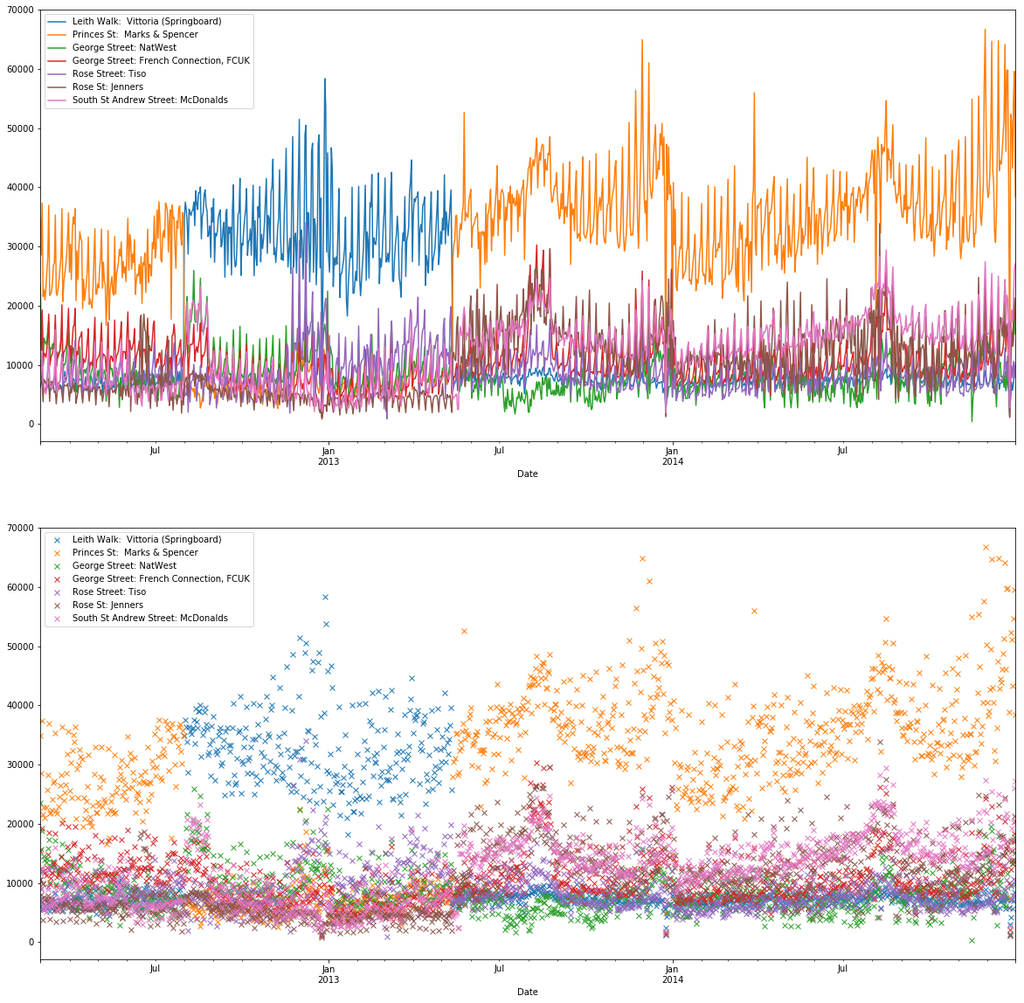

```python
%matplotlib inline
import matplotlib.pyplot as plt

fig, ax = plt.subplots(nrows=2, ncols=1, figsize=(20,20)) #this is how you plot mutiple axes on the same figure

data.plot(x='Date', ax=ax[0]); #ax=ax[0] states this plot should be on axis 0, the top

data.plot(x='Date', style='x', ax=ax[1]);
```

Something weird is going on between August 2012 and May 2013. It looks like the data for Leith Walk and Princes Street has got mixed up!

I've checked online and asked around for any closures around Princes Street during this time, and couldn't find anything.

However, we're going to persist (for now) and instead of analysing each location individually just analyse the total footfall.

Let's add a `Total` column to our `data` and then re-plot it.

```python
data['Total'] = data.sum(axis=1) #add a new axis that is the sum of the other axes

data.head()
```

|  | Date | Leith Walk: Vittoria (Springboard) | Princes St: Marks & Spencer | George Street: NatWest | George Street: French Connection, FCUK | Rose Street: Tiso | Rose St: Jenners | South St Andrew Street: McDonalds | Total |
| --- | --- | --- | --- | --- | --- | --- | --- | --- | --- |
| 0 | 2012-03-01 | 6165 | 34818 | 23458 | 15417 | 10655 | 10582 | 9512 | 110607 |
| 1 | 2012-03-02 | 6906 | 28547 | 15760 | 12428 | 9040 | 8066 | 8877 | 89624 |
| 2 | 2012-03-03 | 7435 | 37333 | 18762 | 19259 | 11980 | 6781 | 12328 | 113878 |
| 3 | 2012-03-04 | 5628 | 21536 | 9809 | 9931 | 5460 | 3751 | 7169 | 63284 |
| 4 | 2012-03-05 | 5887 | 22763 | 14525 | 11956 | 5989 | 7556 | 6109 | 74785 |

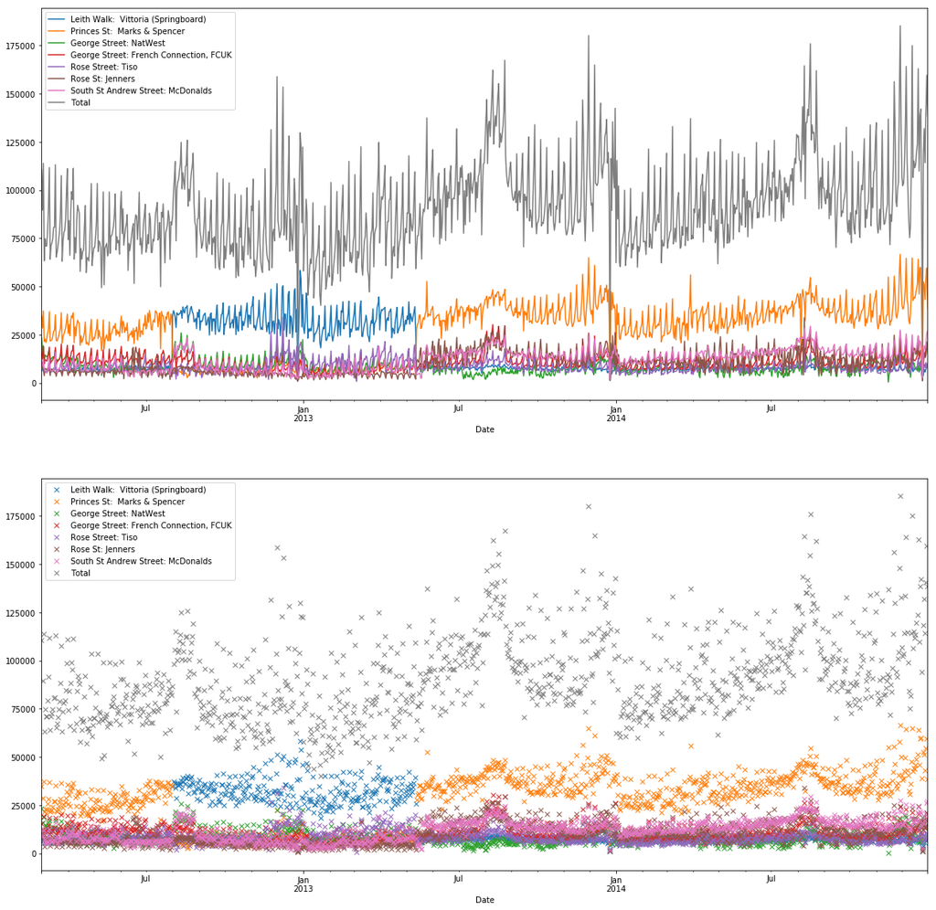

```python
fig, ax = plt.subplots(nrows=2, ncols=1, figsize=(20,20))

data.plot(x='Date', ax=ax[0]);

data.plot(x='Date', style='x', ax=ax[1]);
```

And now let's just view the totals on their own.

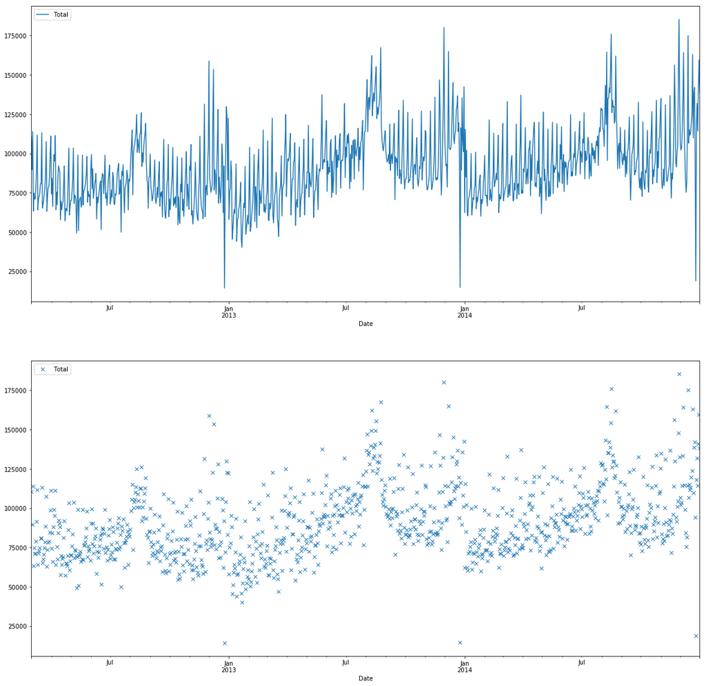

```python
fig, ax = plt.subplots(nrows=2, ncols=1, figsize=(20,20))

data.plot(x='Date', y='Total', ax=ax[0]); #this time we have to explicitly state the y-axis, it defaults to using all columns

data.plot(x='Date', y='Total', style='x', ax=ax[1]);
```

You can probably guess what the dates of the three outliers with sub-25000 footfall are.

But just to be sure:

```python
data.nsmallest(5,'Total') #return the 5 rows with the smallest value in the 'Total' column
```

|  | Date | Leith Walk: Vittoria (Springboard) | Princes St: Marks & Spencer | George Street: NatWest | George Street: French Connection, FCUK | Rose Street: Tiso | Rose St: Jenners | South St Andrew Street: McDonalds | Total |
| --- | --- | --- | --- | --- | --- | --- | --- | --- | --- |
| 24 | 2012-12-25 | 6692 | 1085 | 1366 | 1024 | 1192 | 836 | 2169 | 14364 |
| 24 | 2013-12-25 | 2405 | 4907 | 1204 | 1603 | 1288 | 1442 | 1852 | 14701 |
| 24 | 2014-12-25 | 3028 | 7410 | 1360 | 2139 | 1192 | 1088 | 2735 | 18952 |
| 20 | 2013-01-21 | 18240 | 2881 | 3719 | 3618 | 6100 | 3081 | 2561 | 40200 |
| 12 | 2013-01-13 | 21380 | 3419 | 5037 | 3555 | 6405 | 1506 | 2749 | 44051 |

```python
data.nlargest(5,'Total') #return the 5 rows with the largest value in the 'Total' column
```

|  | Date | Leith Walk: Vittoria (Springboard) | Princes St: Marks & Spencer | George Street: NatWest | George Street: French Connection, FCUK | Rose Street: Tiso | Rose St: Jenners | South St Andrew Street: McDonalds | Total |
| --- | --- | --- | --- | --- | --- | --- | --- | --- | --- |
| 28 | 2014-11-29 | 8977 | 66708 | 17935 | 24216 | 15263 | 24730 | 27423 | 185252 |
| 29 | 2013-11-30 | 8812 | 64929 | 15546 | 25843 | 15913 | 24842 | 24265 | 180150 |
| 15 | 2014-08-16 | 9300 | 54653 | 14328 | 25182 | 15536 | 27539 | 29392 | 175930 |
| 12 | 2014-12-13 | 8476 | 64798 | 17893 | 21194 | 14449 | 23194 | 24992 | 174996 |
| 23 | 2013-08-24 | 9434 | 48546 | 7788 | 29603 | 17672 | 29624 | 24704 | 167371 |

By checking the plots, you can also confirm these results are sensible. August and Late November/Early December are pretty busy times in Edinburgh, no doubt due to The Fringe and tourists visiting in winter.

## Part 3 - Tabulating Data

Let's use some pivot tables to see if we can get anything from the data.

First, let's see if we see any trends in the days of the week.

```python
import numpy as np

#we set the index (the 0th column) to be the date converted into the 'dayofweek'
#dayofweek: 0 = monday, 1 = tuesday, etc.
#aggfunc creates a column with each function applied

pivot_days = pd.pivot_table(data, index=data['Date'].dt.dayofweek, values='Total', aggfunc=[np.mean, np.std, np.max, np.min])

pivot_days
```

| Date | mean Total | std Total | amax Total | amin Total |
| --- | --- | --- | --- | --- |
| 0 | 85272.054054 | 18813.109973 | 140747 | 40200 |
| 1 | 83483.081081 | 19638.024531 | 159597 | 14364 |
| 2 | 84253.216216 | 18602.266898 | 141937 | 14701 |
| 3 | 90707.344595 | 18405.589255 | 143315 | 18952 |
| 4 | 99731.837838 | 17321.822268 | 154391 | 65567 |
| 5 | 117589.162162 | 22071.517289 | 185252 | 67670 |
| 6 | 78870.405405 | 19192.286141 | 132691 | 44051 |

We can also plot this data. Let's look at the means:

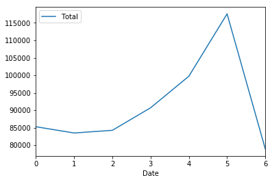

```python
pivot_days.plot(pivot_days.index, 'mean');
```

Looks like Friday and Saturday are the busiest days, with Sunday being the quietest. No surprises there.

How about the months?

```python
#the index is now the month of the year
#month: 1 = january, etc.

pivot_months = pd.pivot_table(data, index=data['Date'].dt.month, values='Total', aggfunc=[np.mean, np.std, np.max, np.min])

pivot_months
```

| Date | mean Total | std Total | amax Total | amin Total |
| --- | --- | --- | --- | --- |
| 1 | 70332.887097 | 15409.319101 | 115396 | 40200 |
| 2 | 78831.446429 | 16170.719640 | 121368 | 50541 |
| 3 | 82449.129032 | 18399.029381 | 137130 | 47159 |
| 4 | 84037.944444 | 16291.818981 | 119884 | 54200 |
| 5 | 85508.838710 | 16496.164809 | 137447 | 49372 |
| 6 | 90273.288889 | 14287.115023 | 131819 | 51555 |
| 7 | 94416.580645 | 15563.980168 | 128836 | 49919 |
| 8 | 119006.784946 | 21699.652144 | 175930 | 65138 |
| 9 | 90991.711111 | 16564.971572 | 133936 | 58772 |
| 10 | 88160.623656 | 17188.476256 | 133830 | 54620 |
| 11 | 93913.611111 | 26623.456784 | 185252 | 55093 |
| 12 | 106818.913978 | 29886.771614 | 174996 | 14364 |

Now let's look at the means per month:

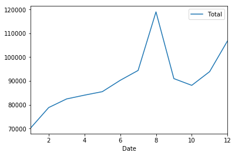

```python
pivot_months.plot(pivot_months.index, 'mean');
```

August and December are pretty busy!

How about getting the visitors per day of the week for each month?

```python
#we can supply multiple indices by using a list

pivot_daypermonth = pd.pivot_table(data, index=[data['Date'].dt.month, data['Date'].dt.dayofweek], values='Total', aggfunc=[np.mean, np.std, np.max, np.min])

pivot_daypermonth
```

| Date | Date | mean Total | std Total | amax Total | amin Total |
| --- | --- | --- | --- | --- | --- |
| 1 | 0 | 58730.625000 | 10784.620941 | 72091 | 40200 |
|  | 1 | 62764.111111 | 7321.619432 | 71825 | 52131 |
|  | 2 | 67684.200000 | 5644.938968 | 75075 | 60585 |
|  | 3 | 75609.100000 | 16244.275597 | 115396 | 54991 |
|  | 4 | 79628.777778 | 9187.748470 | 95292 | 65567 |
|  | 5 | 93032.000000 | 7507.055196 | 102176 | 81625 |
|  | 6 | 54008.625000 | 8760.253094 | 64818 | 44051 |
| 2 | 0 | 72723.000000 | 8856.551522 | 81065 | 53241 |
|  | 1 | 71044.250000 | 7382.563836 | 83955 | 60088 |
|  | 2 | 68166.375000 | 9560.045845 | 87291 | 52708 |
|  | 3 | 78119.625000 | 4730.686569 | 83636 | 70450 |
|  | 4 | 89109.000000 | 8388.353406 | 100366 | 75748 |
|  | 5 | 108210.625000 | 8152.987444 | 121368 | 98842 |
|  | 6 | 64447.250000 | 9213.582950 | 78867 | 50541 |
| 3 | 0 | 69749.461538 | 8469.272830 | 80264 | 55014 |
|  | 1 | 71754.416667 | 9135.509126 | 80775 | 47159 |
|  | 2 | 74792.500000 | 4674.859969 | 81217 | 64753 |
|  | 3 | 83551.846154 | 11143.928047 | 110607 | 67907 |
|  | 4 | 91645.714286 | 9300.903483 | 108023 | 76300 |
|  | 5 | 113181.666667 | 14307.819129 | 137130 | 79678 |
|  | 6 | 66823.142857 | 7263.942147 | 82858 | 57651 |
| 4 | 0 | 76802.428571 | 9794.425602 | 99227 | 64836 |
|  | 1 | 76971.785714 | 9931.616509 | 96569 | 64199 |
|  | 2 | 80422.000000 | 12657.405546 | 100951 | 61773 |
|  | 3 | 89826.833333 | 12381.166451 | 108370 | 69045 |
|  | 4 | 94952.750000 | 9419.099389 | 116667 | 81171 |
|  | 5 | 107690.250000 | 9914.557911 | 119884 | 88010 |
|  | 6 | 65804.000000 | 8936.386276 | 80621 | 54200 |
| 5 | 0 | 82110.583333 | 8888.962405 | 94498 | 69111 |
|  | 1 | 79481.153846 | 8294.720880 | 96223 | 70184 |
| ... | ... | ... | ... | ... | ... |
| 8 | 5 | 141313.357143 | 22699.165402 | 175930 | 114569 |
|  | 6 | 107890.846154 | 16473.632568 | 127161 | 73659 |
| 9 | 0 | 83931.142857 | 13359.175158 | 101013 | 60390 |
|  | 1 | 83679.384615 | 11900.232004 | 99569 | 58772 |
|  | 2 | 87351.500000 | 11522.791309 | 100682 | 68287 |
|  | 3 | 89290.916667 | 14062.144609 | 102315 | 59553 |
|  | 4 | 98603.666667 | 11171.683419 | 112447 | 83625 |
|  | 5 | 115380.846154 | 13359.123966 | 133936 | 94798 |
|  | 6 | 80248.714286 | 11167.233983 | 101167 | 59790 |
| 10 | 0 | 81096.846154 | 9328.716407 | 101187 | 70922 |
|  | 1 | 79524.428571 | 13217.948606 | 97913 | 58101 |
|  | 2 | 83681.066667 | 14784.603036 | 109329 | 55443 |
|  | 3 | 88473.285714 | 10772.863268 | 110358 | 65559 |
|  | 4 | 96169.846154 | 15681.548195 | 125334 | 72665 |
|  | 5 | 115092.500000 | 12735.158260 | 133830 | 97306 |
|  | 6 | 75514.750000 | 10042.363477 | 87239 | 54620 |
| 11 | 0 | 76712.750000 | 9416.085870 | 94111 | 62507 |
|  | 1 | 76267.416667 | 11320.366573 | 91505 | 55093 |
|  | 2 | 79475.750000 | 13314.533004 | 101060 | 57232 |
|  | 3 | 87280.923077 | 14238.832533 | 110648 | 58383 |
|  | 4 | 104482.642857 | 18703.624221 | 147881 | 77466 |
|  | 5 | 135009.642857 | 25993.297055 | 185252 | 94510 |
|  | 6 | 90400.769231 | 24589.549539 | 132691 | 59661 |
| 12 | 0 | 106704.133333 | 17839.373183 | 140747 | 80305 |
|  | 1 | 99720.285714 | 35585.319260 | 159597 | 14364 |
|  | 2 | 87996.076923 | 30170.622318 | 138423 | 14701 |
|  | 3 | 93679.166667 | 29878.006423 | 127891 | 18952 |
|  | 4 | 118375.916667 | 13164.119129 | 133399 | 89433 |
|  | 5 | 144457.769231 | 21434.268225 | 174996 | 98569 |
|  | 6 | 97925.142857 | 18782.173807 | 114732 | 62308 |

84 rows × 4 columns

Let's plot the averages.

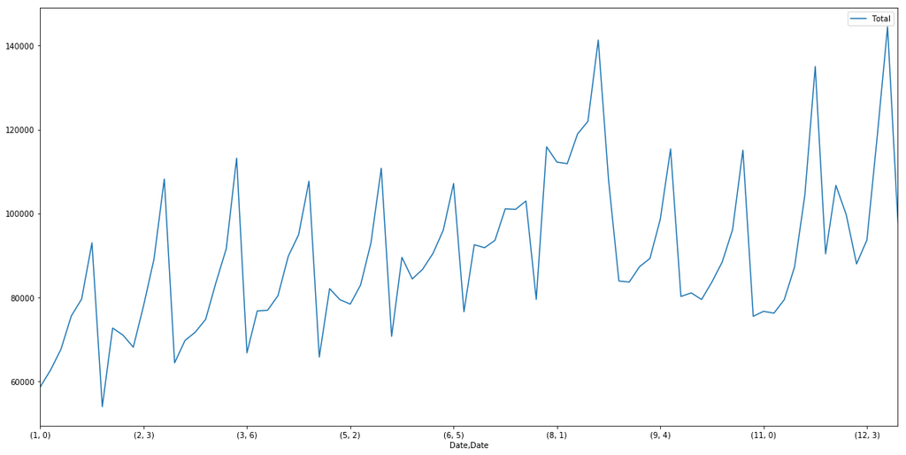

```python
pivot_daypermonth.plot(pivot_daypermonth.index, 'mean', figsize=(20,10));
```

To make things easier to view we'll put an `xtick` every Sunday, add a grid, add axis labels and a title.

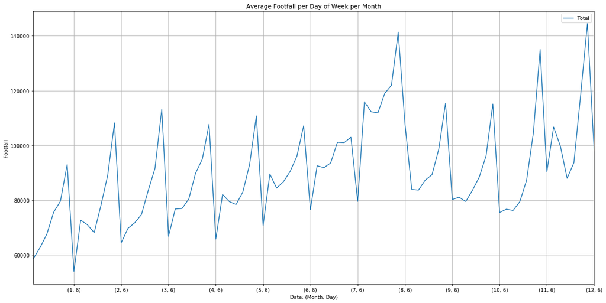

```python
ax = pivot_daypermonth.plot(pivot_daypermonth.index, 'mean', figsize=(20,10), xticks=[6+(7*x) for x in range(12)], grid=True)
ax.set_xlabel('Date: (Month, Day)')
ax.set_ylabel('Footfall')
ax.set_title('Average Footfall per Day of Week per Month');
```

This pretty much confirms what we've already found out (Saturdays are most busy, Sunday the least busy, August is very busy, etc.), but it's nice to see it graphically.

Finally, let's get the average per day of the year. We have to use `fillna(0)` to handle the `NaN` left in by not being able to calculate the `std` for the extra leap year day as it only has one entry in our data (the very last row).

```python
pivot_dayofyear = pd.pivot_table(data, index=data['Date'].dt.dayofyear, values='Total', aggfunc=[np.mean, np.std, np.max, np.min]).fillna(0)

pivot_dayofyear
```

| Date | mean Total | std Total | amax Total | amin Total |
| --- | --- | --- | --- | --- |
| 1 | 60210.000000 | 3008.032247 | 62337 | 58083 |
| 2 | 95235.500000 | 28511.252524 | 115396 | 75075 |
| 3 | 81341.000000 | 5221.276472 | 85033 | 77649 |
| 4 | 98734.000000 | 4867.723082 | 102176 | 95292 |
| 5 | 75226.000000 | 18217.899110 | 88108 | 62344 |
| 6 | 52890.500000 | 10467.301682 | 60292 | 45489 |
| 7 | 61124.500000 | 14169.712788 | 71144 | 51105 |
| 8 | 65955.000000 | 9425.733393 | 72620 | 59290 |
| 9 | 69923.500000 | 7981.114239 | 75567 | 64280 |
| 10 | 70160.500000 | 11655.241074 | 78402 | 61919 |
| 11 | 85947.500000 | 19801.111194 | 99949 | 71946 |
| 12 | 77155.500000 | 22987.334350 | 93410 | 60901 |
| 13 | 54765.000000 | 15151.884107 | 65479 | 44051 |
| 14 | 64724.500000 | 10041.623400 | 71825 | 57624 |
| 15 | 64670.000000 | 8652.158575 | 70788 | 58552 |
| 16 | 71023.000000 | 9321.081590 | 77614 | 64432 |
| 17 | 73212.000000 | 9643.522282 | 80031 | 66393 |
| 18 | 85764.000000 | 21387.151704 | 100887 | 70641 |
| 19 | 73221.500000 | 11884.343671 | 81625 | 64818 |
| 20 | 58966.500000 | 18560.845899 | 72091 | 45842 |
| 21 | 54736.000000 | 20557.008343 | 69272 | 40200 |
| 22 | 63343.000000 | 15856.162461 | 74555 | 52131 |
| 23 | 69125.500000 | 10984.903846 | 76893 | 61358 |
| 24 | 75720.000000 | 10384.570189 | 83063 | 68377 |
| 25 | 75934.000000 | 14661.152001 | 86301 | 65567 |
| 26 | 75901.000000 | 22484.581428 | 91800 | 60002 |
| 27 | 59674.500000 | 15630.595398 | 70727 | 48622 |
| 28 | 60244.000000 | 11196.328773 | 68161 | 52327 |
| 29 | 63615.500000 | 10177.387902 | 70812 | 56419 |
| 30 | 70938.500000 | 14642.060118 | 81292 | 60585 |
| ... | ... | ... | ... | ... |
| 337 | 93475.000000 | 9641.174047 | 103703 | 84554 |
| 338 | 95920.333333 | 17111.201955 | 114212 | 80305 |
| 339 | 95756.333333 | 32639.435677 | 133399 | 75321 |
| 340 | 118505.333333 | 43583.137351 | 164156 | 77336 |
| 341 | 119948.333333 | 42609.648324 | 164926 | 80187 |
| 342 | 108516.666667 | 12600.990609 | 122831 | 99099 |
| 343 | 113534.000000 | 35848.718820 | 153485 | 84174 |
| 344 | 84786.000000 | 15244.829386 | 102372 | 75319 |
| 345 | 91925.000000 | 11690.440496 | 104598 | 81562 |
| 346 | 105999.333333 | 16460.936709 | 116626 | 87038 |
| 347 | 127159.000000 | 50645.695602 | 174996 | 74108 |
| 348 | 113060.333333 | 29370.336606 | 145129 | 87470 |
| 349 | 110750.000000 | 4438.057120 | 115175 | 106299 |
| 350 | 115261.333333 | 11415.701877 | 128054 | 106112 |
| 351 | 98080.000000 | 25808.969371 | 113250 | 68280 |
| 352 | 106292.666667 | 18601.960443 | 119611 | 85039 |
| 353 | 109300.666667 | 28812.280374 | 127891 | 76111 |
| 354 | 120512.000000 | 47836.872348 | 162968 | 68682 |
| 355 | 108389.666667 | 29021.368168 | 136642 | 78656 |
| 356 | 119512.000000 | 16926.338263 | 138509 | 106034 |
| 357 | 120048.333333 | 21760.239000 | 142079 | 98569 |
| 358 | 83458.000000 | 18317.881291 | 94263 | 62308 |
| 359 | 41896.333333 | 43474.215120 | 92036 | 14701 |
| 360 | 82971.666667 | 59423.081259 | 118194 | 14364 |
| 361 | 97813.333333 | 30777.437845 | 131913 | 72094 |
| 362 | 117912.000000 | 16010.947474 | 135450 | 104077 |
| 363 | 126214.000000 | 16621.361527 | 140747 | 108091 |
| 364 | 127833.000000 | 29580.786011 | 159597 | 101074 |
| 365 | 121324.666667 | 33162.951532 | 142449 | 83102 |
| 366 | 122330.000000 | 0.000000 | 122330 | 122330 |

366 rows × 4 columns

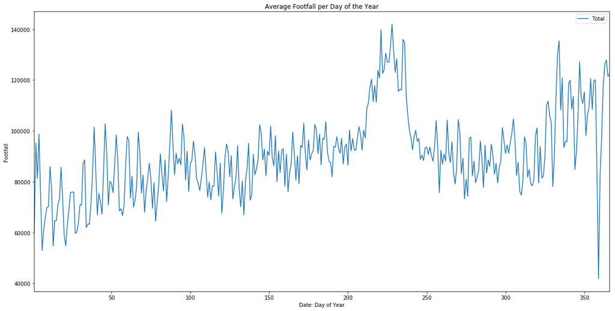

```python
ax = pivot_dayofyear.plot(pivot_dayofyear.index, 'mean', figsize=(20,10))
ax.set_xlabel('Date: Day of Year')
ax.set_ylabel('Footfall')
ax.set_title('Average Footfall per Day of the Year');
```

## Part 4 - Clustering Data

Finally, we're going to use principal component analysis (PCA) and Gaussian mixture models to automatically find clusters in the data.

```python
pivot = pd.pivot_table(data, index=data['Date'], values=data.columns[1:-1]).fillna(0) #use columns[:-1] to ignore the 'Total' column

pivot
```

| Date | George Street: French Connection, FCUK | George Street: NatWest | Leith Walk: Vittoria (Springboard) | Princes St: Marks & Spencer | Rose St: Jenners | Rose Street: Tiso | South St Andrew Street: McDonalds |
| --- | --- | --- | --- | --- | --- | --- | --- |
| 2012-03-01 | 15417 | 23458 | 6165 | 34818 | 10582 | 10655 | 9512 |
| 2012-03-02 | 12428 | 15760 | 6906 | 28547 | 8066 | 9040 | 8877 |
| 2012-03-03 | 19259 | 18762 | 7435 | 37333 | 6781 | 11980 | 12328 |
| 2012-03-04 | 9931 | 9809 | 5628 | 21536 | 3751 | 5460 | 7169 |
| 2012-03-05 | 11956 | 14525 | 5887 | 22763 | 7556 | 5989 | 6109 |
| 2012-03-06 | 11779 | 13892 | 5533 | 20985 | 7185 | 6017 | 5468 |
| 2012-03-07 | 11253 | 13480 | 5726 | 22841 | 6815 | 6012 | 5100 |
| 2012-03-08 | 12665 | 14047 | 5985 | 25722 | 7326 | 7228 | 6116 |
| 2012-03-09 | 14803 | 15818 | 6682 | 28174 | 7850 | 9284 | 8894 |
| 2012-03-10 | 18564 | 17305 | 6661 | 36945 | 7279 | 12194 | 12732 |
| 2012-03-11 | 9850 | 10119 | 5250 | 21728 | 3830 | 6279 | 7059 |
| 2012-03-12 | 10788 | 12847 | 5731 | 21956 | 7088 | 6689 | 6157 |
| 2012-03-13 | 11637 | 12683 | 5981 | 22406 | 7210 | 6709 | 6027 |
| 2012-03-14 | 11776 | 13471 | 6027 | 24102 | 6836 | 6359 | 6357 |
| 2012-03-15 | 13188 | 13608 | 6307 | 26892 | 6355 | 7450 | 6883 |
| 2012-03-16 | 13547 | 12829 | 6997 | 27209 | 5331 | 8171 | 6649 |
| 2012-03-17 | 18398 | 17128 | 8353 | 35327 | 5547 | 12526 | 15927 |
| 2012-03-18 | 9563 | 9745 | 5848 | 22131 | 3423 | 5584 | 8930 |
| 2012-03-19 | 10921 | 12161 | 5309 | 21740 | 5523 | 6433 | 5384 |
| 2012-03-20 | 11540 | 11324 | 6434 | 22957 | 5718 | 6987 | 5746 |
| 2012-03-21 | 11894 | 12080 | 6045 | 24502 | 6041 | 7080 | 6923 |
| 2012-03-22 | 12665 | 12310 | 6689 | 26500 | 5947 | 7140 | 7458 |
| 2012-03-23 | 14463 | 14320 | 6219 | 28261 | 6460 | 9251 | 9440 |
| 2012-03-24 | 20143 | 16564 | 6205 | 36366 | 5210 | 11842 | 11219 |
| 2012-03-25 | 10615 | 8261 | 5313 | 20679 | 3620 | 5920 | 8704 |
| 2012-03-26 | 12098 | 10122 | 6786 | 23912 | 6315 | 6911 | 7343 |
| 2012-03-27 | 12339 | 9997 | 8894 | 25317 | 6573 | 7114 | 7988 |
| 2012-03-28 | 12859 | 10569 | 7463 | 26669 | 6468 | 7145 | 7922 |
| 2012-03-29 | 13501 | 12199 | 8044 | 28594 | 6418 | 7740 | 8156 |
| 2012-03-30 | 16076 | 13631 | 9451 | 31756 | 6855 | 10129 | 10862 |
| ... | ... | ... | ... | ... | ... | ... | ... |
| 2014-12-02 | 9945 | 13589 | 6869 | 38273 | 12093 | 6280 | 15231 |
| 2014-12-03 | 11009 | 12807 | 7009 | 39039 | 11855 | 6735 | 15249 |
| 2014-12-04 | 11920 | 15007 | 7243 | 42665 | 13802 | 7393 | 16182 |
| 2014-12-05 | 15230 | 19535 | 8575 | 49547 | 10293 | 9897 | 20322 |
| 2014-12-06 | 22935 | 18796 | 7943 | 64668 | 11495 | 12890 | 25429 |
| 2014-12-07 | 13638 | 15321 | 6111 | 43028 | 12225 | 7053 | 17356 |
| 2014-12-08 | 9973 | 15708 | 6630 | 40533 | 5282 | 6612 | 14361 |
| 2014-12-09 | 8509 | 8860 | 5623 | 32311 | 11378 | 5097 | 12396 |
| 2014-12-10 | 7768 | 5968 | 5397 | 30671 | 8341 | 5334 | 11840 |
| 2014-12-11 | 8476 | 2911 | 5430 | 36158 | 10322 | 5097 | 13168 |
| 2014-12-12 | 13701 | 7983 | 7178 | 47502 | 10454 | 8832 | 18684 |
| 2014-12-13 | 21194 | 17893 | 8476 | 64798 | 23194 | 14449 | 24992 |
| 2014-12-14 | 13013 | 9623 | 5843 | 42828 | 11585 | 7551 | 16139 |
| 2014-12-15 | 11726 | 10413 | 6893 | 44444 | 18028 | 7496 | 16175 |
| 2014-12-16 | 11506 | 7971 | 6929 | 43927 | 17834 | 7243 | 16208 |
| 2014-12-17 | 12011 | 8019 | 7335 | 46058 | 14846 | 7720 | 17261 |
| 2014-12-18 | 12868 | 7777 | 6985 | 48792 | 17970 | 7825 | 17394 |
| 2014-12-19 | 14598 | 6194 | 7065 | 51335 | 14588 | 8983 | 21137 |
| 2014-12-20 | 20401 | 8829 | 8172 | 64136 | 24379 | 12871 | 24180 |
| 2014-12-21 | 12283 | 6056 | 5623 | 46079 | 15098 | 7846 | 16886 |
| 2014-12-22 | 15748 | 7641 | 7201 | 59723 | 15878 | 10556 | 21762 |
| 2014-12-23 | 16307 | 11498 | 7311 | 59833 | 16979 | 9152 | 20999 |
| 2014-12-24 | 9985 | 5859 | 5767 | 38844 | 13712 | 5784 | 14312 |
| 2014-12-25 | 2139 | 1360 | 3028 | 7410 | 1088 | 1192 | 2735 |
| 2014-12-26 | 12280 | 9421 | 4162 | 52345 | 17230 | 7133 | 15623 |
| 2014-12-27 | 15415 | 13813 | 7064 | 51128 | 15416 | 9809 | 19268 |
| 2014-12-28 | 13758 | 13336 | 5678 | 43235 | 13140 | 7802 | 17260 |
| 2014-12-29 | 16960 | 17319 | 6957 | 54657 | 13948 | 10607 | 20299 |
| 2014-12-30 | 18425 | 17833 | 8528 | 59581 | 21302 | 7830 | 26098 |
| 2014-12-31 | 20451 | 15158 | 9862 | 38375 | 17042 | 10385 | 27150 |

1036 rows × 7 columns

```python
X = pivot

X.shape
```

```
(1036, 7)
```

Now let's use PCA to reduce the dimensionality from 7 to 2 so we can plot it.

```python
from sklearn.decomposition import PCA

X2 = PCA(2).fit_transform(X) #PCA into 2 dimensions, fit_transform both fits the model and applies the dimensionality reduction

X2.shape
```

```
(1036, 2)
```

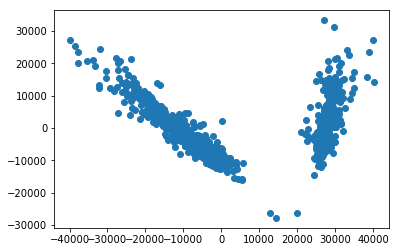

```python
plt.scatter(X2[:,0], X2[:,1]);
```

The clusters look pretty distinct!

Now we'll use a Gaussian mixture model to automatically cluster the data.

```python
from sklearn.mixture import GaussianMixture

gmm = GaussianMixture(2) #state the number of clusters
gmm.fit(X) #fit to our data
labels = gmm.predict(X) #get a list with the label for each data point in X
```

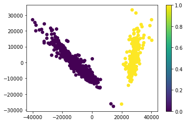

```python
plt.scatter(X2[:,0], X2[:,1], c=labels);
plt.colorbar();
```

Now let's plot the data for each label to see if we can figure out what the distinct clusters are.

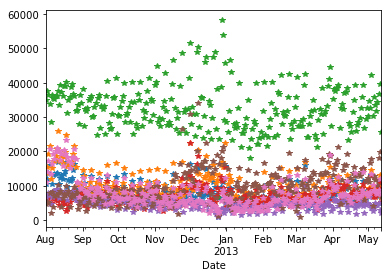

```python
pivot[labels==1].plot(style='*', legend=False);
```

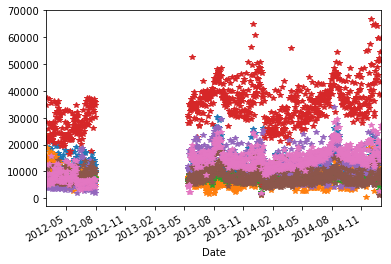

```python
pivot[labels==0].plot(style='*', legend=False);
```

Let's put them on comparable axes using `sharex = True` so things are a little easier to see.

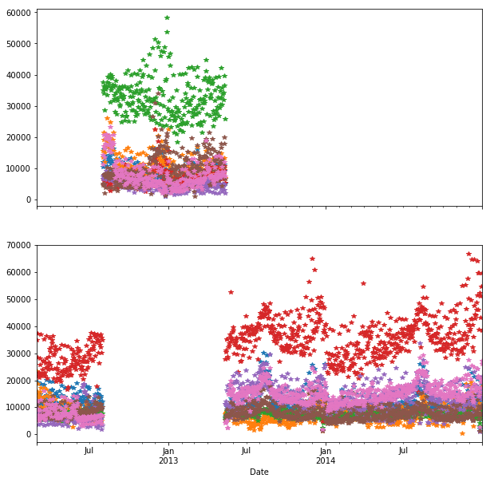

```python
fig, ax = plt.subplots(nrows=2, ncols=1, sharex=True, figsize=(10,10)) #sharex = True means we want both subplots to share the same x-axis

pivot[labels==1].plot(style='*', legend=False, ax=ax[0]);

pivot[labels==0].plot(style='*', legend=False, ax=ax[1]);
```

So what are these clusters?

Remember when we said that it looked like the data for Leith Walk and Princes Street got switched up between August 2012 and May 2013? It looks like that's what we've found!